# Aula5

```python
import numpy as np
import matplotlib.pyplot as plt
```

Função $z^n$ e composição de funções.

- Estudamos o conceito de uma função complexa. Dados um conjunto de pontos $z=x+iy$, realizamos, por f aplicado a $z$, uma transformação de $z$ para $w=u+iv$.
- Estudamos três casos simples de transformação: translação, rotação e dilatação.
- Por exemplo, a translação $$w=az+b,\hspace{2 cm} a=1,b \in \mathbb{C}$$
- Obtemos $w$ e fazemos sua representação gráfica de uma plano complexo $w$ formado pelos eixos da parte imaginária e real, da mesma foma que para o plano complexo $z$ contendo os pontos $z=x+iy$
- Se $f$ e $g$ são duas funções, a composição de $f$ e $g$ é escrita como $f \circ g(z)$.
- Calculamos a transformação $g$ em $z$ e em seguinda $f(g(z))$, $$f\circ g(z) =f(g(z))$$
- Da mesa forma é calculada a imagem $S^{``}$ de $S$ sob a transformação $f\circ g(z) =f(g(z))$ é determinada primeiramente encontrando $S^`$,$S$ sob $g$, e em seguida encontrando a imagem $S^{``}$, de $S^{`}$ sob $f$.
- Definimos a transformação linear complexa $$f(z)=az+b,\hspace{2cm}a,b\in\mathbb{C}$$
- Qualquer transformação linear complexa pode ser descrita como a composição de três tipos básicos de operações:
- $$\frac{a}{|a|}z=\frac{|a|e^{i\theta}}{|a|}z$$
- $$|a|z_1$$
- $$z_2+b$$
- $$f(z)=T\circ D \circ R$$
- onde $f(z)$ é a transformação linear
- $T$ é a translação
- $D$ é a dilatação
- $R$ é a rotação.
- $$f(z)=T(D(R(z)))$$

Por exemplo, $f(z)=3z+i$, é realizada uma rotação por $0$ rad, uma dilatação por $3$ e uma translação por $i$.

- A função $f(z)=zz=z^2$ também pode ser representada como uma composição $h\circ g(z)$, dilatação (contração) e rotação.
- Em geral, o ponto $z$ define se a operação vai ser uma composição de rotação, dilatação ou contração.
- $$f(|z|=1)=|z|^2e^{i\theta}=e^{i\theta}$$
- $$f(z=i)=1^2e^{i2\pi/2}=-1$$
- Na forma geral $$z^=r^ne^{in\theta}$$

Duas transformações comutam se a ordem não importa para todos os pontos em que elas são aplicadas.

```python
t=np.arange(0,np.pi/2,.001)
z=(2)+2*np.exp(1j*t)
```

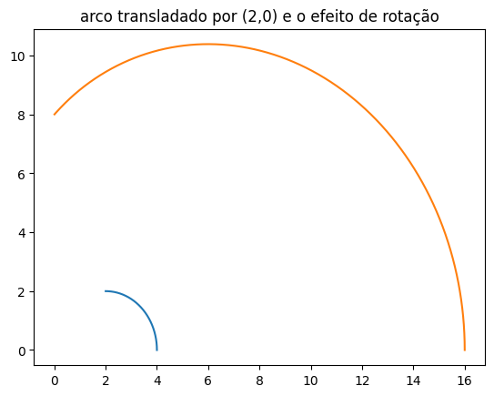

```python
plt.title("arco transladado por (2,0) e o efeito de rotação")
plt.plot(z.real,z.imag)
plt.plot((z*z).real,(z*z).imag)
#plt.xlim(0,5)
#plt.ylim(0,5)
```

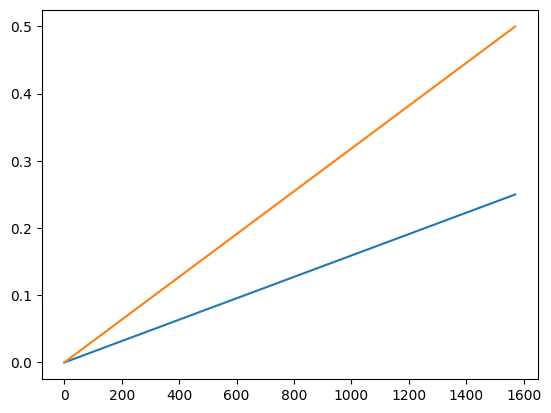

```python
plt.plot(np.angle(z)/np.pi)
plt.plot(np.angle(z*z)/np.pi)
```

```python
a
```